# Homework 10

Anusha Ramamurthy

April 10, 2016

Problem Set A

Water was sampled at each of k = 3 sites (A,B,C) in the Bimini Lagoon, Bahamas. The salinity of each experimental unit was measured in parts per million (ppm). The resulting data are presented in Table 12.2. These data were analyzed by Till, and appear as Data Set 253 in A Handbook of Small Data Sets. A 37.54 37.01 36.71 37.03 37.32 37.01 37.03 37.70 37.36 36.75 37.45 38.85 B 40.17 40.80 39.76 39.70 40.79 40.44 39.79 39.38 C 39.04 39.21 39.05 38.24 38.53 38.71 38.89 38.66 38.51 40.08

1. Use side-by-side boxplots and normal probability plots to investigate the ANOVA assumptions of normality and homoscedasticity. Do these assumptions seem plausible? Why or why not?

```r
a = c(37.54, 37.01, 36.71, 37.03, 37.32, 37.01, 37.03, 37.70, 37.36, 36.75, 37.45, 38.85)
b = c (40.17, 40.80, 39.76, 39.70, 40.79, 40.44, 39.79, 39.38)
c = c (39.04, 39.21, 39.05, 38.24, 38.53, 38.71, 38.89, 38.66, 38.51, 40.08)

summary(a)
```

```
##    Min. 1st Qu.  Median    Mean 3rd Qu.    Max.
##   36.71   37.01   37.17   37.31   37.47   38.85
```

```r
summary(b)
```

```
##    Min. 1st Qu.  Median    Mean 3rd Qu.    Max.
##   39.38   39.75   39.98   40.10   40.53   40.80
```

```r
summary(c)
```

```
##    Min. 1st Qu.  Median    Mean 3rd Qu.    Max.
##   38.24   38.56   38.80   38.89   39.05   40.08
```

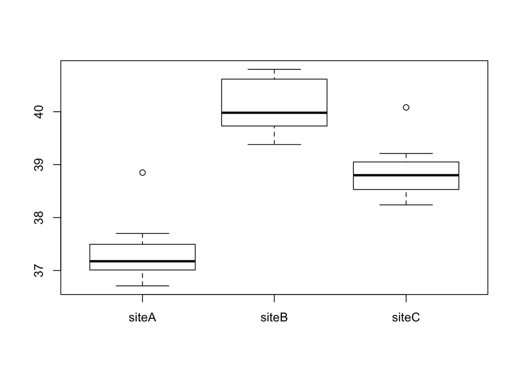

```r
boxplot(a,b,c,names = c("siteA","siteB","siteC"))
```

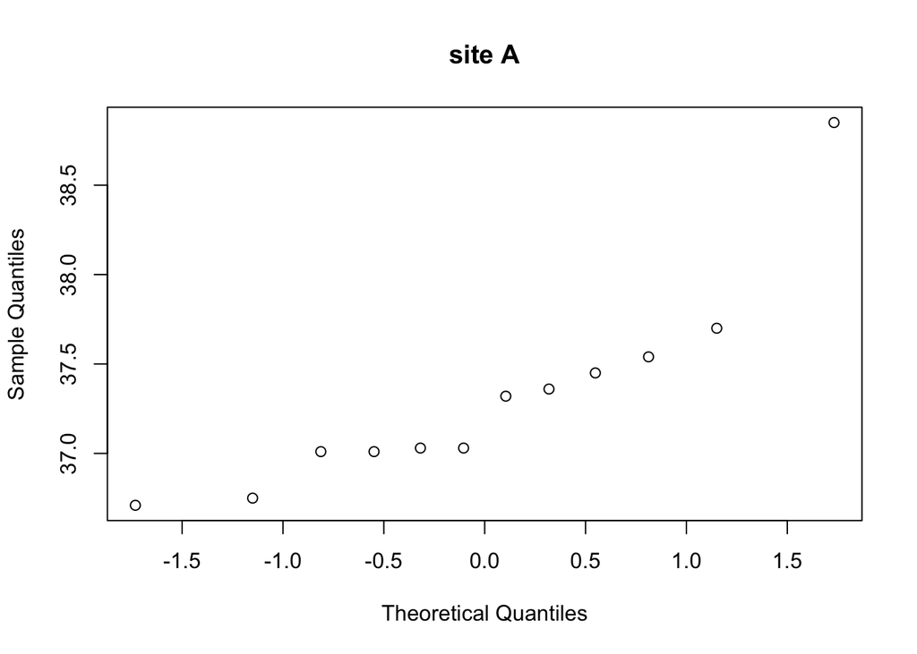

```r
qqnorm(a,main="site A")
```

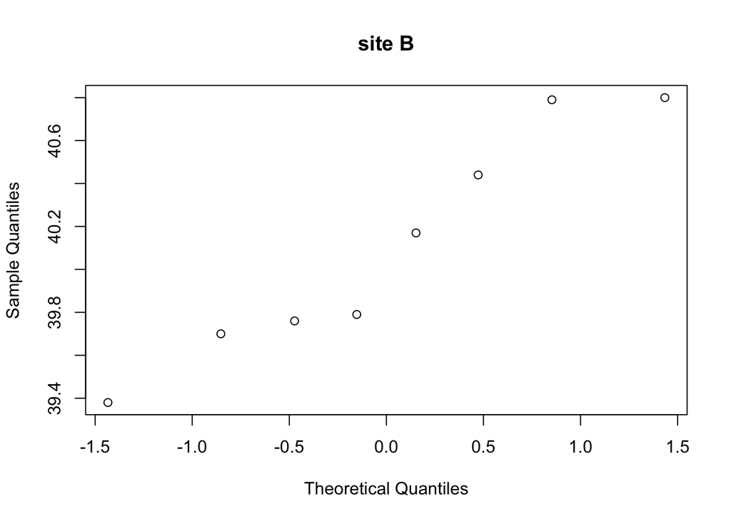

```r
qqnorm(b,main="site B")
```

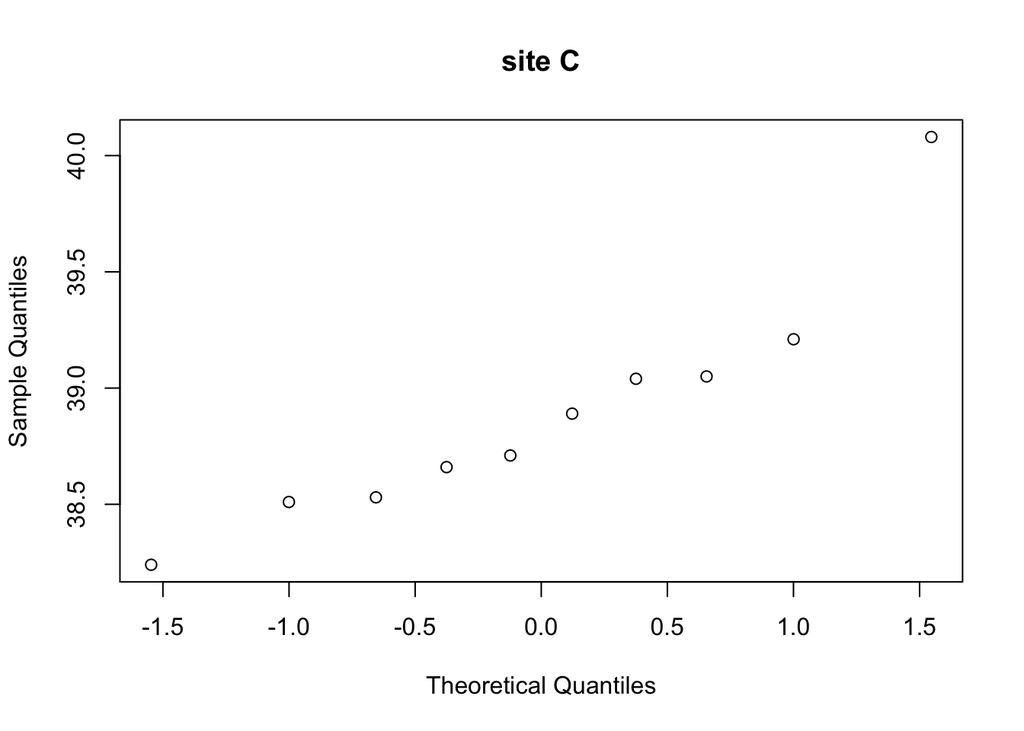

```r
qqnorm(c,main="site C")
```

```r
sd(a)
```

```
## [1] 0.5727975
```

```r
sd(b)
```

```
## [1] 0.5313846
```

```r
sd(c)
```

```
## [1] 0.510812
```

- Answer: As we see, from the qqplots, there is a systematic bend in the graphs., especially in the case of samples from Site A. So the normal assumption is questionable. However, we see that all the standard deviations of the samples are very close, so the homoscedasticity is plausible.
2. Use ANOVA to test the null hypothesis that the three sites have the same mean salinity. Use a significance level of α = 0.05 and organize your calculations in an ANOVA table.

```r
n1 = length(a)
n2 = length(b)
n3 = length(c)
N=n1+n2+n3

n1.mean = mean(a)
n2.mean = mean(b)
n3.mean = mean(c)

abc = c(a,b,c)
grand.mean = mean(abc)

SST = sum((abc-grand.mean)^2)
total.df = N-1

SSB = (n1*(n1.mean-grand.mean)^2) + (n2 * (n2.mean- grand.mean)^2) + (n3 *(n3.mean-grand.mean)^2)
between.df = 2
between.meansq = SSB/2

SSW = (n1-1)*var(a)+(n2-1)*var(b)+(n3-1)*var(c)
within.df = N-3
within.meansq = SSW/within.df

Fscore = between.meansq/within.meansq
pval=1-pf(Fscore,df1=between.df,df2=within.df)

columns = c("Sum of squares", "DF", "MeanSquare", "F-score", "P-value")

#rows = c("Between","Within","Total")

Between= c(SSB,"2",between.meansq,Fscore,round(pval,4))
Within = c(SSW,within.df,within.meansq,'','')
Total = c(SST,total.df,'','','')

anova_table <- data.frame(rbind(Between,Within,Total))
colnames(anova_table) = columns
anova_table
```

```
##           Sum of squares DF       MeanSquare          F-score P-value
## Between       38.8008825  2      19.40044125 66.0210459354486       0
## Within  7.93401416666666 27 0.29385237654321
## Total   46.7348966666666 29
```

- Answer: The p-score is very small, close to zero. Hence we reject the null hypothesis for significance value of 0.05 as p < 0.05, p < α

Problem Set B

Steady-state hemoglobin levels were measured on a total of N = 41 patients with k = 3 types of sickle cell disease. The k = 3 types are HB SS, HB ST (HB S/-thalassemia), and HB SC. The resulting data are presented in Table 12.3. These data were analyzed by Anionwu and colleagues,4 and appear as Data Set 310 in A Handbook of Small Data Sets.

```r
SS = c( 7.2, 7.7, 8.0, 8.1, 8.3, 8.4, 8.4, 8.5, 8.6, 8.7,9.1, 9.1, 9.1, 9.8, 10.1, 10.3)
ST = c(8.1, 9.2, 10.0, 10.4, 10.6, 10.9, 11.1, 11.9, 12.0, 12.1)
SC =c(10.7 ,11.3, 11.5, 11.6, 11.7, 11.8, 12.0, 12.1, 12.3, 12.6,12.6, 13.3, 13.3, 13.8, 13.9)
```

1. Use side-by-side boxplots and normal probability plots to investigate the ANOVA assumptions of normality and homoscedasticity. Do these assumptions seem plausible? Why or why not?

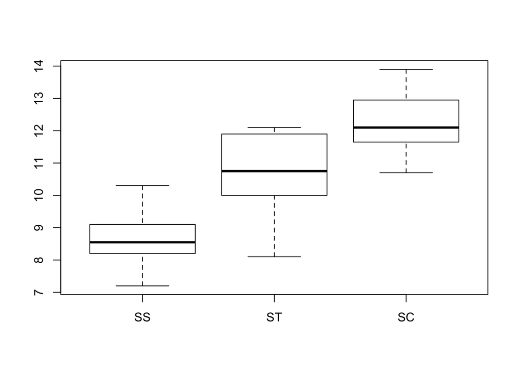

```r
boxplot(SS,ST,SC,names = c("SS","ST","SC"))
```

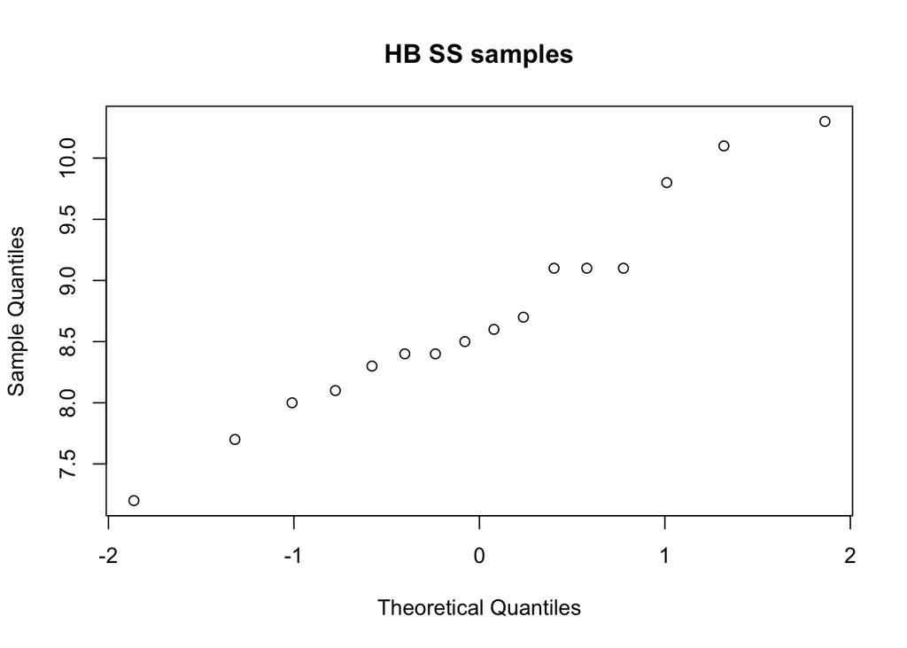

```r
qqnorm(SS,main="HB SS samples")
```

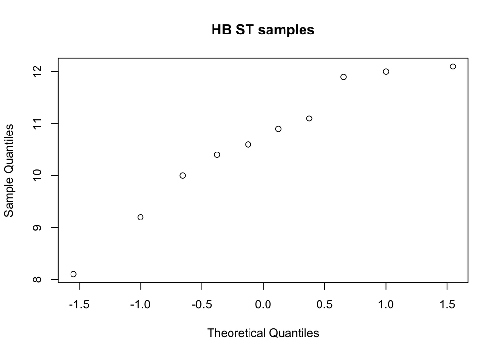

```r
qqnorm(ST,main="HB ST samples")
```

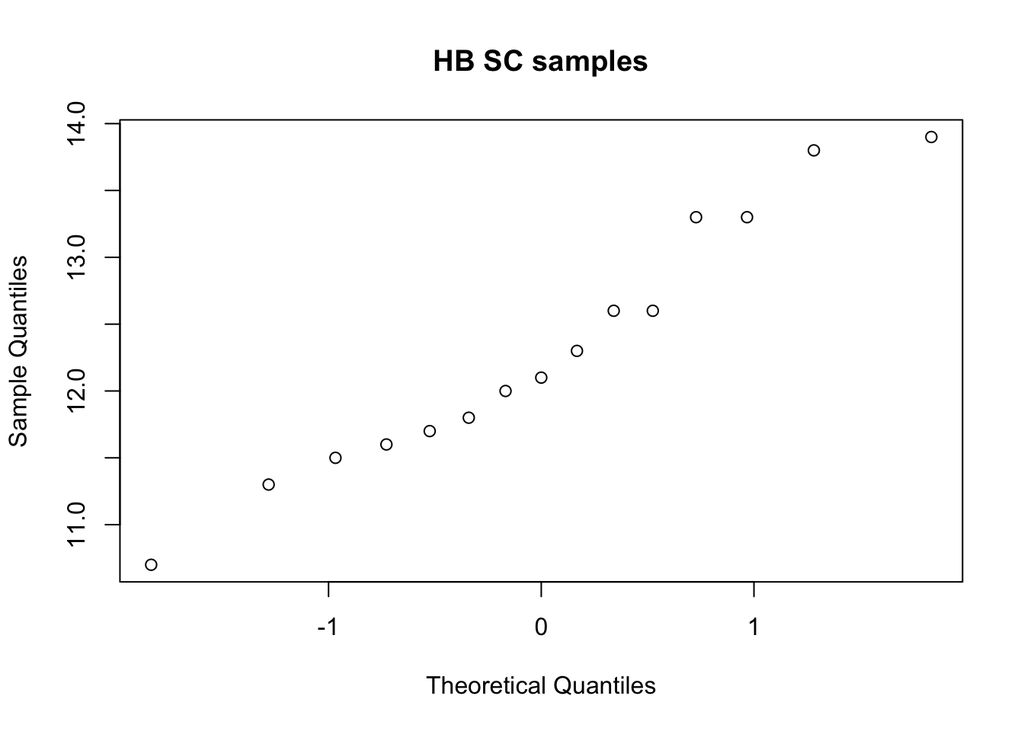

```r
qqnorm(SC,main="HB SC samples")
```

```r
sd(SS)
```

```
## [1] 0.844492
```

```r
sd(ST)
```

```
## [1] 1.284134
```

```r
sd(SC)
```

```
## [1] 0.9418826
```

- Answer: The qqplots are almost straight lines, so the assumption of normality looks plausible. However the standard deviations are not very close to each other, so the assumption of homoscedasticity is questionable.
2. Use ANOVA to test the null hypothesis that the three types of sickle cell disease have the same mean hemoglobin levels. Use a significance level of α = 0.05 and organize your calculations in an ANOVA table.

```r
n1 = length(SS)
n2 = length(ST)
n3 = length(SC)
N=n1+n2+n3

n1.mean = mean(SS)
n2.mean = mean(ST)
n3.mean = mean(SC)

abc = c(SS,ST,SC)
grand.mean = mean(abc)

SST = sum((abc-grand.mean)^2)
total.df = N-1

SSB = (n1*(n1.mean-grand.mean)^2) + (n2 * (n2.mean- grand.mean)^2) + (n3 *(n3.mean-grand.mean)^2)
between.df = 2
between.meansq = SSB/2

SSW = (n1-1)*var(SS)+(n2-1)*var(ST)+(n3-1)*var(SC)
within.df = N-3
within.meansq = SSW/within.df

Fscore = between.meansq/within.meansq
pval=1-pf(Fscore,df1=between.df,df2=within.df)

columns = c("Sum of squares", "DF", "MeanSquare", "Fscore", "P-value")

#rows = c("Between","Within","Total")

Between= c(SSB,"2",between.meansq,Fscore,round(pval,4))
Within = c(SSW,within.df,within.meansq,'','')
Total = c(SST,total.df,'','','')

anova_table <- data.frame(rbind(Between,Within,Total))
colnames(anova_table) = columns
anova_table
```

```
##           Sum of squares DF        MeanSquare           Fscore P-value
## Between 99.8893048780488  2  49.9446524390244 49.9992568906286       0
## Within           37.9585 38 0.998907894736842
## Total   137.847804878049 40
```

- Answer: The pvalue is very small < 0.05. Hence we reject the null hypothesis.

Problem Set G

Researchers compared antibody responses in normal and alloxan diabetic mice. Three groups of mice were studied: normal, alloxan diabetic, and alloxan diabetic treated with insulin. Several comparisons are of interest:

• Does the antibody response of alloxan diabetic mice differ from the antibody response of normal mice?

• Does the antibody response of alloxan diabetic mice treated with insulin differ from the antibody response of normal mice?

• Does treating alloxan diabetic mice with insulin affect their antibody response?

Table 12.7 contains the measured amounts of nitrogen-bound bovine serum albumen produced by the mice. These data were analyzed by Dolkart and colleagues,8 and appear as Data Set 304 in A Handbook of Small Data Sets.

1. Using the above data, investigate the ANOVA assumptions of normality and homoscedasticity. Do these assumptions seem plausible for these data? Why or why not?

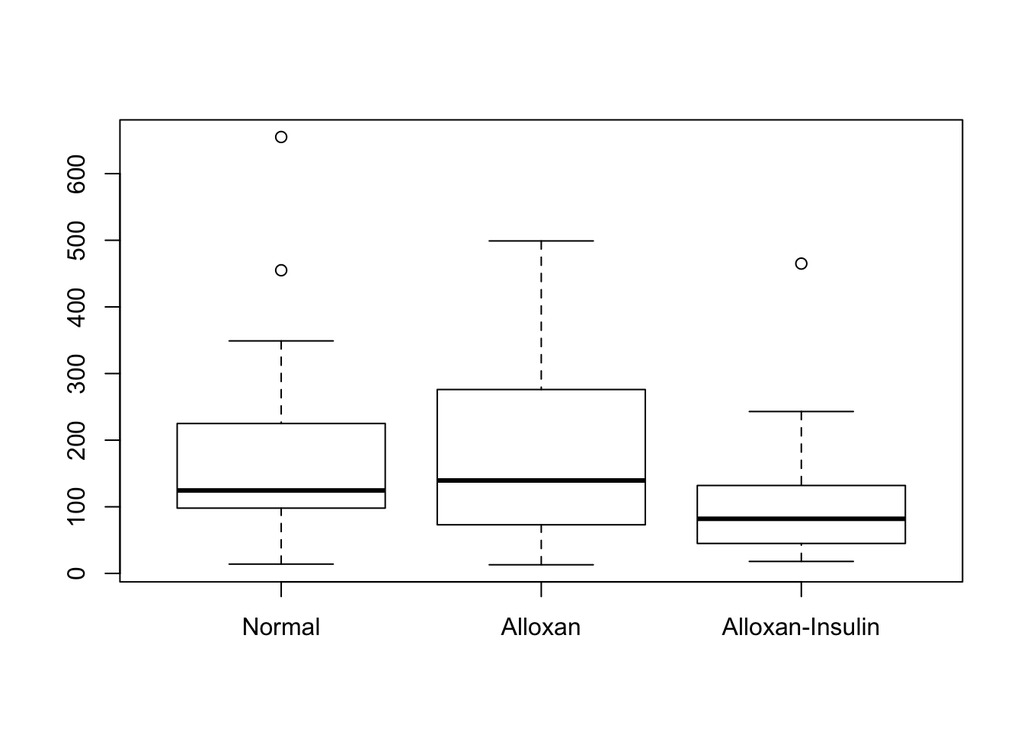

```r
normal = c(156,282,197,197,116,127,119,29,253,122,349,110,143,64,26,86,122,455,655,14)
alloxan = c(391,46,469,86,174,133,13,499,168,62,127,276,176,146,108,276,50,73)
alloxan_i = c(82,100,98,150,243,68,228,131,73,18,20,100,72,133,465,40,46,34,44)

boxplot(normal,alloxan,alloxan_i,names = c("Normal","Alloxan","Alloxan-Insulin"))
```

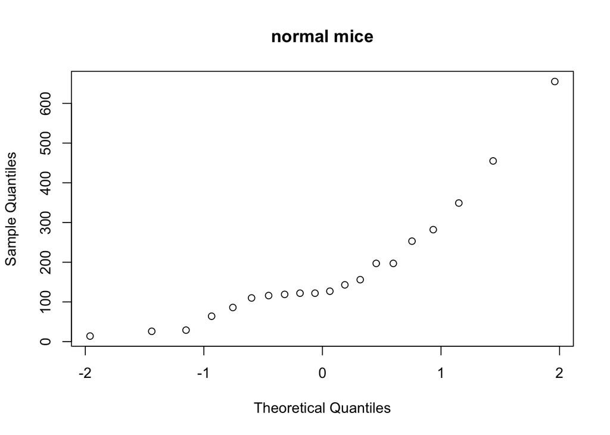

```r
qqnorm(normal,main="normal mice")
```

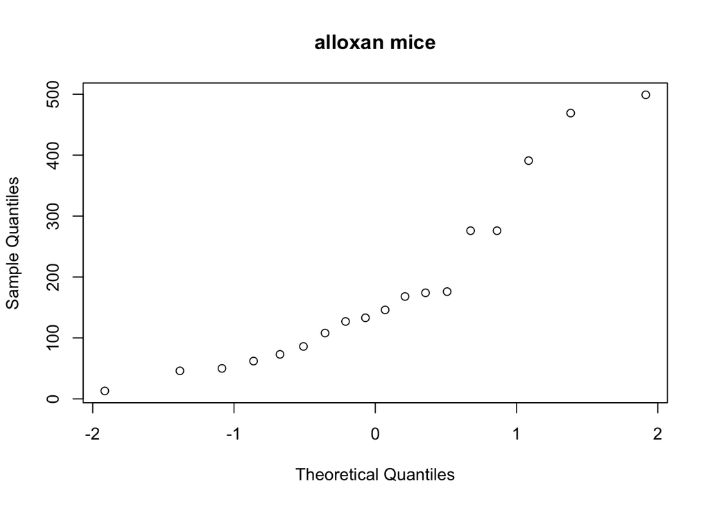

```r
qqnorm(alloxan,main="alloxan mice")
```

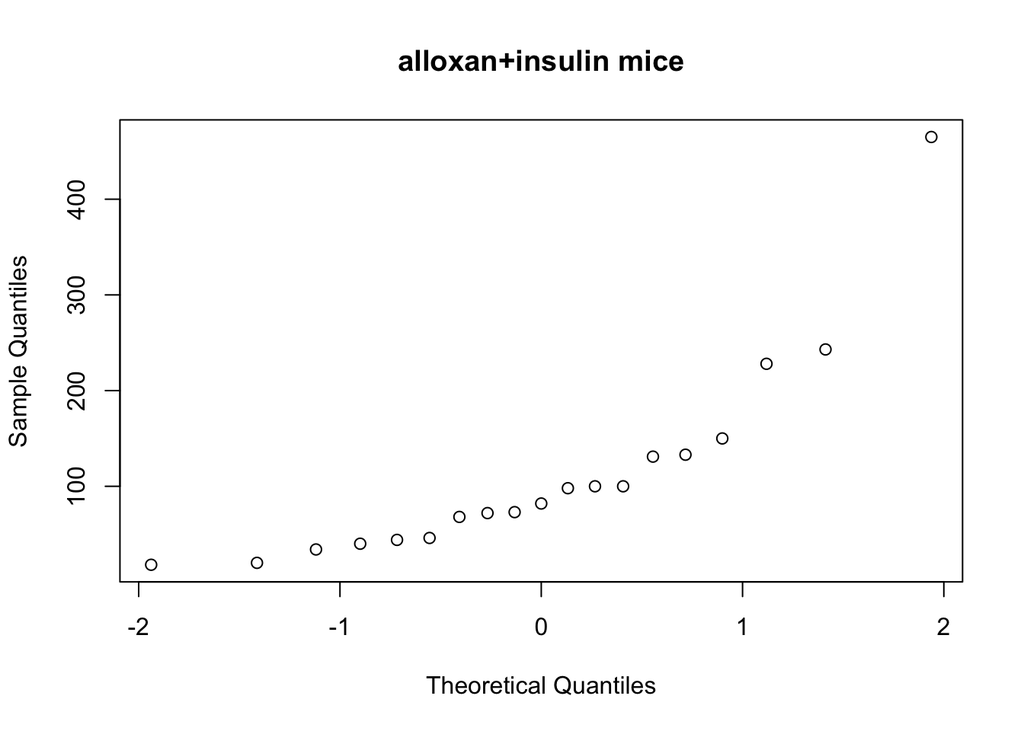

```r
qqnorm(alloxan_i,main="alloxan+insulin mice")
```

```r
sd(normal)
```

```
## [1] 156.72
```

```r
sd(alloxan)
```

```
## [1] 144.8493
```

```r
sd(alloxan_i)
```

```
## [1] 105.7896
```

- Answer: The qqplots show systematic bends and don’t have a straight line. The standard deviations also show large variations and are not close to each other. So the assumptions of normality and homoscedasticity don’t seem plausible.
2. Now transform the data by taking the square root of each measurement. Using the transformed data, investigate the ANOVA assumptions of normality and homoscedasticity. Do these assumptions seem plausible for the transformed data? Why or why not?

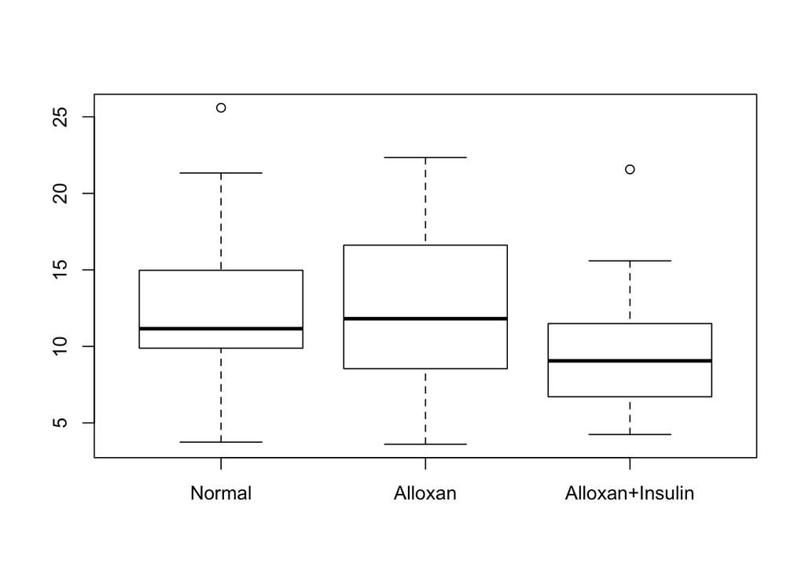

```r
sq_normal = sqrt(c(156,282,197,197,116,127,119,29,253,122,349,110,143,64,26,86,122,455,655,14))
sq_alloxan = sqrt(c(391,46,469,86,174,133,13,499,168,62,127,276,176,146,108,276,50,73))
sq_alloxan_i = sqrt(c(82,100,98,150,243,68,228,131,73,18,20,100,72,133,465,40,46,34,44))

boxplot(sq_normal,sq_alloxan,sq_alloxan_i,names = c("Normal","Alloxan","Alloxan+Insulin"))
```

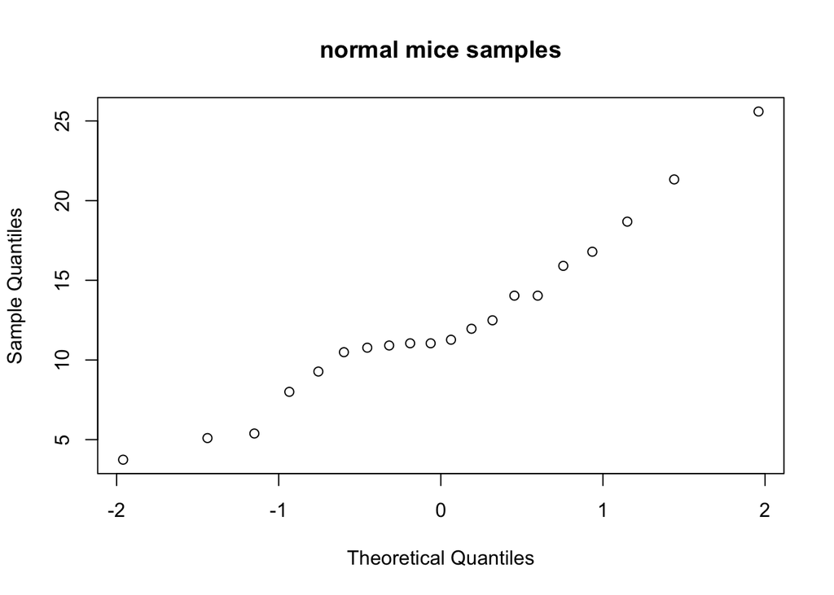

```r
qqnorm(sq_normal,main="normal mice samples")
```

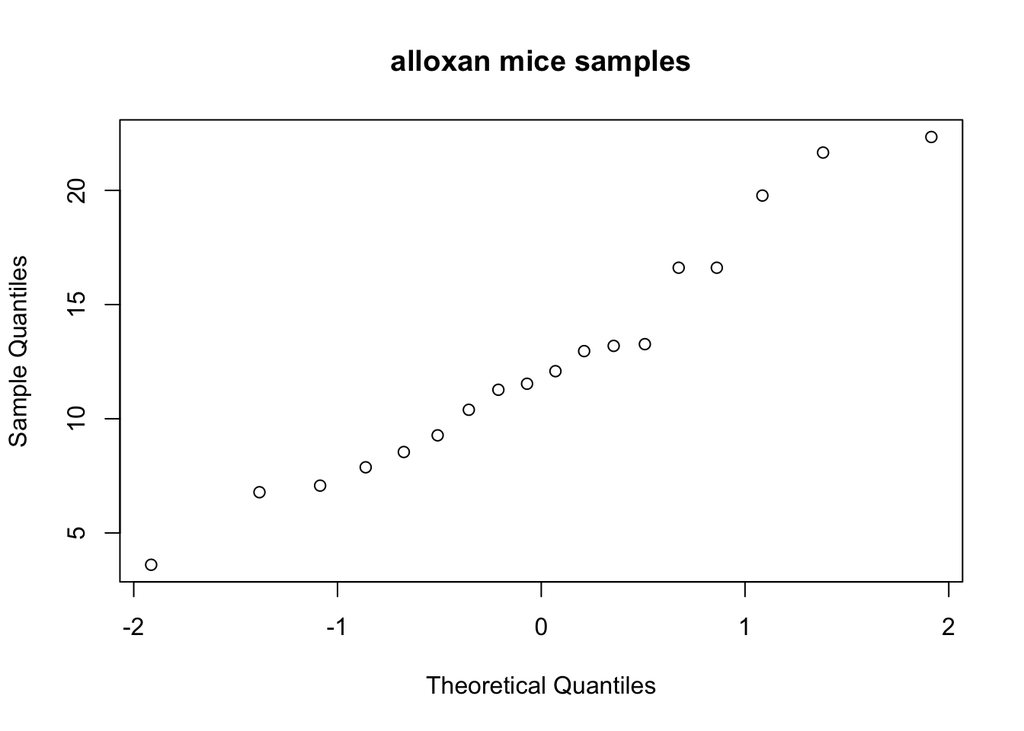

```r
qqnorm(sq_alloxan,main="alloxan mice samples")
```

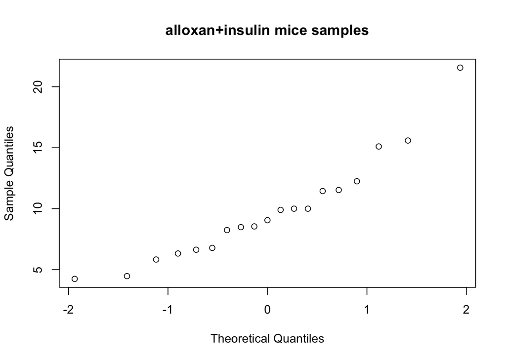

```r
qqnorm(sq_alloxan_i,main="alloxan+insulin mice samples")
```

```r
sd(sq_normal)
```

```
## [1] 5.382764
```

```r
sd(sq_alloxan)
```

```
## [1] 5.226939
```

```r
sd(sq_alloxan_i)
```

```
## [1] 4.244474
```

- Answer:After the transformations the graphs appear closer to a straight line. The standard deviations are also quite close now. Hence the assumptions of normality and homoscedasticity seem more plausible now than in the previous data without transformation.
3. Using the transformed data, construct an ANOVA table. State the null and alternative hypotheses tested by this method. Should the null hypothesis be rejected at the α = 0.05 level?
- Answer: The null hypothesis is that there is no difference between the samples taken from normal, alloxan and alloxan-insulin treated mice. The alternate hypothesis is that there is a difference between normal, alloxan and alloxan insulin mice.

```r
n1 = length(sq_normal)
n2 = length(sq_alloxan)
n3 = length(sq_alloxan_i)
N=n1+n2+n3

n1.mean = mean(sq_normal)
n2.mean = mean(sq_alloxan)
n3.mean = mean(sq_alloxan_i)

abc = c(sq_normal,sq_alloxan,sq_alloxan_i)
grand.mean = mean(abc)

SST = sum((abc-grand.mean)^2)
total.df = N-1

SSB = (n1*(n1.mean-grand.mean)^2) + (n2 * (n2.mean- grand.mean)^2) + (n3 *(n3.mean-grand.mean)^2)
between.df = 2
between.meansq = SSB/2

SSW = (n1-1)*var(sq_normal)+(n2-1)*var(sq_alloxan)+(n3-1)*var(sq_alloxan_i)
within.df = N-3
within.meansq = SSW/within.df

Fscore = between.meansq/within.meansq
pval=1-pf(Fscore,df1=between.df,df2=within.df)

columns = c("Sum of squares", "DF", "MeanSquare", "F-statistic", "P-value")

#rows = c("Between","Within","Total")

Between= c(SSB,"2",between.meansq,Fscore,round(pval,4))
Within = c(SSW,within.df,within.meansq,'','')
Total = c(SST,total.df,'','','')

anova_table <- data.frame(rbind(Between,Within,Total))
colnames(anova_table) = columns
anova_table
```

```
##           Sum of squares DF       MeanSquare      F-statistic P-value
## Between 89.0520989000002  2 44.5260494500001 1.79534603754224  0.1758
## Within  1339.24414570884 54 24.8008175131267
## Total   1428.29624460884 56
```

• Does the antibody response of alloxan diabetic mice differ from the antibody response of normal mice?

- Answer: μ1 = mean of antibody responses of normal mice population

μ2 = mean of antibody responses of Alloxan mice population

μ3 = mean of antibody responses of Alloxan + insulin mice population

∆1 = μ1 − μ2 Null Hypothesis: H0 : ∆1 = 0 Alternative hypothesis: H1 : ∆1 not equal to 0

```r
t =(n1.mean-n2.mean)/sqrt(((1/n1)+(1/n2))*25.175)
2*pt(-t,df=54)
```

```
## [1] 1.04805
```

- Answer: The p-value is large. So we dont reject the null hypothesis.

• Does the antibody response of alloxan diabetic mice treated with insulin differ from the antibody response of normal mice?

- Answer: ∆2 = μ2 − μ3 Null Hypothesis: H0 : ∆2 = 0 Alternative hypothesis: H1 : ∆2 not equal to 0

```r
t =(n2.mean-n3.mean)/sqrt(((1/n2)+(1/n3))*25.175)
2*pt(-t,df=54)
```

```
## [1] 0.1073873
```

- Answer: The p-value is large. So we dont reject the null hypothesis.

• Does treating alloxan diabetic mice with insulin affect their antibody response?

- Answer: ∆3 = μ3 − μ2 H0 : ∆3 > 0, Alternative hypothesis: H1 : ∆3 ≤ 0

```r
t =(n3.mean-n2.mean)/sqrt(((1/n3)+(1/n2))*25.175)
pt(t,df=54)
```

```
## [1] 0.05369364
```

- Answer: The p-value is very close to 0.05. I would say it is border line and I wouldnt reject the null hyppothesis without a higher p-value.